# Final Project

Taufiq Ahmad

2024-11-22

## The Role of Artificial Intelligence in Crisis Communication: A computational analysis of organizational Press Releases

#Project Overview:

This project investigates how U.S. organizations frame AI in press releases concerning disaster response and management. More specifically, I would focus on how AI is framed in organizational press releases related to disaster management, what are key themes and dominant narratives related the discussions of AI in the context of natural disasters and crises in United States and finally what potential risks and ethical concerns regarding AI usage are highlighted in these communications?

#Objective of the Project:

Analyze how U.S. organizations frame AI in press releases during disaster response and management efforts.

## RQs

1. How do organizational press releases frame the role of AI in identifying and mitigating disaster risks in the United States?
2. What strategies and systems related to AI are highlighted in organizational press releases for disaster preparedness?
3. How do organizations use AI to engage stakeholders for disaster preparedness?

## Data collection

1. States News Service
2. Targeted News Service
3. PR Newswire
4. Business Wire
5. GlobeNewswire

These press releases explicitly mention “Artificial Intelligence” or “AI” in conjunction with disasters.

## A Quick Overview of the data

Dominant Headlines of the Press Releases: Ethical Concerns Public Trust AI Benefits AI Limitations

Regional Focus: United States

Organizations Highlighted: FEMA Department of Homeland Security Major Tech Companies Non-Governmental Organizations (NGOs)

## Data Analysis Approach

A computational textual analysis approach is employed to analyze the collected press releases. The analysis is conducted using R programming, leveraging various libraries and packages to facilitate data processing and analysis. The key steps include:

Data Cleaning and Preparation:

1. Content Analysis:
2. Sentimental Analysis:
3. Topic Modeling & Thematic Analyis:
4. Visualization and Reporting:

Expected Outcomes

1. Comprehensive Understanding
2. Theme Identification
3. Ethical Insights
4. Strategic Recommendations

##Repository Highlights

1. GitHub Repository: FramingAI
2. Data Access: FramingAI Data Repository
3. Codebook Structure
4. Data Samples
5. Descriptive Statistics
6. Analytical Tools

## Appropriate libraries

```r
library(tidyverse)
library(pdftools)
library(tidyverse)
library(textdata)
library(tidytext)
library(quanteda)
library(rio)
library(janitor)
library(rio)
library(dplyr)
library(stringr)
library(readr)
here::here()
#topic modeling
library(tm)
library(topicmodels)
library(lda)
library(ldatuning)
# from tutorial packages
library(DT)
library(knitr)
library(kableExtra)
library(reshape2)
library(ggplot2)
library(wordcloud)
library(pals)
library(SnowballC)
library(flextable)
```

## loading the Data

#Here I am starting with uploading PDF data, reading the files, converting theim into text and them combining the text, and spliting into the documents.

```r
#reading PDF file and converting it into text.
text <- pdf_text("../data/FramingAI.PDF")
writeLines(text, "../data/FramingAI.text")
file_path <- "../data/FramingAI.text"
text_data <- readLines(file_path)
text_combined <- paste(text_data, collapse = "\n")
documents <- strsplit(text_combined, "End of Document")[[1]]
output_dir <- "../data/extracted"
for (i in seq_along(documents)) {
  output_file <- file.path(output_dir, paste0("FramingAI_extracted", i, ".txt"))
  writeLines(documents[[i]], output_file)
}
cat("Files created:", length(documents), "\n")
```

```
## Files created: 501
```

```r
FramingAI_index <- read_lines("../data/extracted/FramingAI_extracted1.txt")
extracted_lines <-FramingAI_index[20:2360]
cat(head(extracted_lines, 20), sep = "\n")
```

```
##
##   2. Here are the people Trump has picked for key positions so far
##
##
##   3. Here are the people Trump has picked for key positions so far
##
##
##   4. REPS LIEU AND KILEY INTRODUCE BILL TO INCREASE PENALTIES FOR FRAUD USING AI
##
##
##   5. REPS LIEU AND KILEY INTRODUCE BILL TO INCREASE PENALTIES FOR FRAUD USING AI
##
##
##   6. COMER ANNOUNCES FULL COMMITTEE MARKUP ON NOVEMBER 20
##
##
##   7. COP29: DIGITAL TECH TO PLEDGE FOR REDUCED CLIMATE FOOTPRINT AND INCREASED
##   ACTION AT THE FIRST-EVER DIGITALISATION DAY
```

```r
extracted_lines <- extracted_lines |>
  as.data.frame()
```

## Build a final dataframe index

```r
cleaned_data <- extracted_lines |>
  mutate(
    trimmed_line = str_trim(extracted_lines),
    is_title = str_detect(trimmed_line, "^\\d+\\. "),

    # Detect dates (e.g., "Aug 14, 2024")
    is_date = str_detect(trimmed_line, "\\b\\w{3} \\d{1,2}, \\d{4}\\b")
  )

# Shifting dates to align with corresponding titles
aligned_data <- cleaned_data |>
  mutate(
    date = ifelse(lead(is_date, 1), lead(trimmed_line, 1), NA_character_)  # Shift date to title's row
  ) |>
  filter(is_title) |>
  select(trimmed_line, date)  # Keep only the relevant columns

# Step 3: Rename columns for clarity
final_data <- aligned_data |>
  rename(
    title = trimmed_line,
    date = date
  )

# Date and Publication in separate columns, and formatted
final_data <- separate(data = final_data, col = date, into = c("date2", "publication"), sep = "  ", extra = "merge", fill = "right")


#Step 5: Format date, clean headline
final_data <- final_data |>
  mutate(date = as.Date(date2,format = "%b %d, %Y")) |>
  mutate(title =str_remove(title, "^\\d+\\. ")) |>
  subset(select = -(date2)) |>
  mutate(index = row_number()) |>
  select(index, date, title, publication)

write_csv(final_data, "./final_data.csv")
```

## Text compiler

```r
# Define function to loop through each text file

create_article_text <- function(row_value) {
  temp <- final_index %>%
    slice(row_value)


  temp_filename <- temp$filename

  articles_df_temp <- read_lines(temp$filepath) %>%
    as_tibble() %>%
    mutate(filename = temp_filename)

  articles_df <<- articles_df %>%
    bind_rows(articles_df_temp)
}

articles_df <- tibble()
row_values <- 1:nrow(final_index)

lapply(row_values, create_article_text)


# Clean up articles_df and join to index dataframe
articles_df <- articles_df %>%
  select(filename, sentence=value) %>%
  inner_join(final_index)

#After viewing articles_df, I see 2022 lines from the index that I don't need. Cutting them

articles_df <- articles_df %>%
  slice(-c(1:2022)) |>
  #gets rid of blank rows
    filter(trimws(sentence) != "")

write_csv(articles_df, "./articles_df.csv")
```

## top 20 bigrams

```r
top_20_bigrams <- bigrams |>
   top_n(20) |>
  mutate(bigram = paste(word1, " ", word2)) |>
  select(bigram, n)
```

## Visualization of bigrams

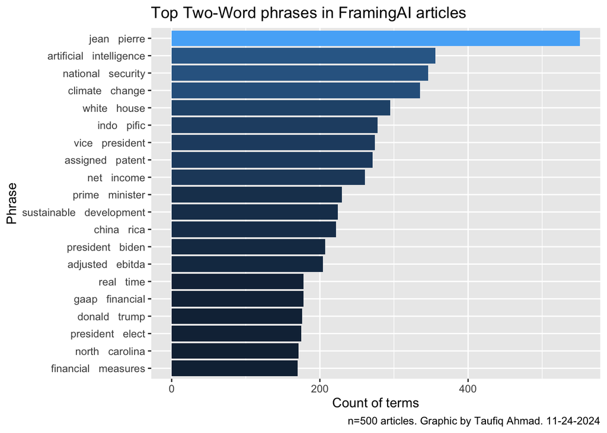

```r
ggplot(top_20_bigrams, aes(x = reorder(bigram, n), y = n, fill=n)) +
  geom_bar(stat = "identity") +
  theme(legend.position = "none") +
  coord_flip() +
  labs(title = "Top Two-Word phrases in FramingAI articles",
       caption = "n=500 articles. Graphic by Taufiq Ahmad. 11-24-2024",
       x = "Phrase",
       y = "Count of terms")
```

## Sentiment Analysis

```r
library(textdata)
library(quanteda)
```

#Tokenize text

```r
text_tokenized <- articles_df %>%
  select(sentence) %>%
  unnest_tokens(word, sentence)
```

#Filter tokenized text

```r
text_tokenized <- articles_df %>%
  select(sentence) %>%
  mutate(sentence = str_replace_all(sentence, "- ", "")) %>%
  unnest_tokens(word, sentence) %>%
  filter(!word %in% stop_words$word) %>%
  filter(word != "stories_corpus") %>%
  filter(!grepl('[0-9]', word))
```

## word count

```r
text_word_ct <- text_tokenized %>%
  count(word, sort=TRUE)
text_word_ct
```

```
## # A tibble: 33,279 × 2
##    word            n
##    <chr>       <int>
##  1 article      4085
##  2 page         2524
##  3 data         2413
##  4 ai           2321
##  5 based        1695
##  6 president    1689
##  7 security     1683
##  8 development  1680
##  9 research     1660
## 10 including    1577
## # ℹ 33,269 more rows
```

## Loading NRC lexicon

```r
nrc_sentiments <- get_sentiments("nrc")

nrc_sentiments %>% count(sentiment)
```

```
## # A tibble: 10 × 2
##    sentiment        n
##    <chr>        <int>
##  1 anger         1245
##  2 anticipation   837
##  3 disgust       1056
##  4 fear          1474
##  5 joy            687
##  6 negative      3316
##  7 positive      2308
##  8 sadness       1187
##  9 surprise       532
## 10 trust         1230
```

```r
nrc_sentiments %>%
  group_by(word) %>%
  count() %>%
  arrange(desc(n)) %>%
  distinct()
```

```
## # A tibble: 6,453 × 2
## # Groups:   word [6,453]
##    word          n
##    <chr>     <int>
##  1 feeling      10
##  2 treat        10
##  3 weight        9
##  4 celebrity     8
##  5 intense       8
##  6 obliging      8
##  7 opera         8
##  8 supremacy     8
##  9 vote          8
## 10 death         7
## # ℹ 6,443 more rows
```

## Counting Overall Sentiment with NRC

```r
sentiments_all <- text_tokenized %>%
  inner_join(nrc_sentiments)
sentiments_all %>%
  group_by(word) %>%
    count(sentiment) %>%
  arrange(desc(n))
```

```
## # A tibble: 7,034 × 3
## # Groups:   word [3,272]
##    word        sentiment        n
##    <chr>       <chr>        <int>
##  1 president   positive      1689
##  2 president   trust         1689
##  3 including   positive      1577
##  4 technology  positive      1487
##  5 information positive      1320
##  6 trump       surprise      1208
##  7 management  positive      1061
##  8 management  trust         1061
##  9 time        anticipation  1003
## 10 income      anticipation   986
## # ℹ 7,024 more rows
```

```r
sentiments_all <- text_tokenized %>%
  inner_join(nrc_sentiments) %>%
  count(sentiment, sort = TRUE) %>%
  mutate(pct_total =round(n/sum(n), digits=2))
sentiments_all
```

```
## # A tibble: 10 × 3
##    sentiment        n pct_total
##    <chr>        <int>     <dbl>
##  1 positive     76850      0.31
##  2 trust        46692      0.19
##  3 negative     26758      0.11
##  4 anticipation 24922      0.1
##  5 fear         18274      0.07
##  6 joy          16142      0.07
##  7 anger        11789      0.05
##  8 sadness      11438      0.05
##  9 surprise      8686      0.04
## 10 disgust       5700      0.02
```

## Visualizing the sentimental Analysis

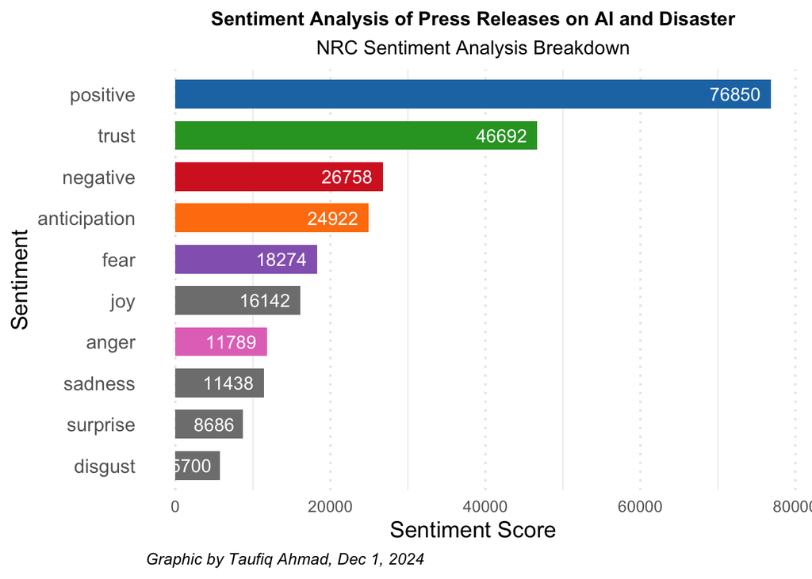

```r
nrc_plot <- sentiments_all %>%
  ggplot(aes(x = reorder(sentiment, n), y = n, fill = sentiment)) +
  geom_bar(stat = "identity", position = "dodge", width = 0.7) +
  geom_text(aes(label = n), hjust = 1.2, size = 4, color = "white") +
  labs(
    title = "Sentiment Analysis of Press Releases on AI and Disaster",
    subtitle = "NRC Sentiment Analysis Breakdown",
    caption = "Graphic by Taufiq Ahmad, Dec 1, 2024",
    x = "Sentiment",
    y = "Sentiment Score"
  ) +
  theme_minimal(base_size = 14) +
  theme(
    plot.title = element_text(face = "bold", size = 12, hjust = 0.5),  # Center and bold title
    plot.subtitle = element_text(size = 12, hjust = 0.5),  # Center subtitle
    plot.caption = element_text(hjust = 0, size = 10, face = "italic"),
    axis.text.x = element_text(size = 10, color = "grey40"),
    axis.text.y = element_text(size = 12, color = "grey40"),
    panel.grid.major.x = element_line(color = "grey90", linetype = "dotted"),  # Dotted grid lines
    panel.grid.major.y = element_blank(),  # Remove unnecessary grid lines
    legend.position = "none"  # Hide legend since colors are self-explanatory
  ) +
  scale_fill_manual(values = c(
    "positive" = "#1f77b4",   # Blue
    "negative" = "#d62728",   # Red
    "trust" = "#2ca02c",      # Green
    "fear" = "#9467bd",       # Purple
    "anticipation" = "#ff7f0e", # Orange
    "anger" = "#e377c2"       # Pink
  )) +  # Vibrant colors for each sentiment
  coord_flip()  # Flip for better readability

# Print the enhanced plot
print(nrc_plot)
```

## Checking the top words in some of the sentiments

## Positive

```r
nrc_positive <- nrc_sentiments %>%
  filter(sentiment == "positive")
FramingAI_positive <- text_tokenized %>%
  inner_join(nrc_positive) %>%
  count(word, sort = TRUE)
FramingAI_positive
```

```
## # A tibble: 1,413 × 2
##    word            n
##    <chr>       <int>
##  1 president    1689
##  2 including    1577
##  3 technology   1487
##  4 information  1320
##  5 management   1061
##  6 income        986
##  7 cooperation   924
##  8 public        892
##  9 share         800
## 10 growth        794
## # ℹ 1,403 more rows
```

## Trust

```r
#Trust
nrc_trust <- nrc_sentiments %>%
  filter(sentiment == "trust")
FramingAI_trust <- text_tokenized %>%
  inner_join(nrc_trust) %>%
  count(word, sort = TRUE)
FramingAI_trust
```

```
## # A tibble: 791 × 2
##    word             n
##    <chr>        <int>
##  1 president     1689
##  2 management    1061
##  3 income         986
##  4 cooperation    924
##  5 committee      916
##  6 system         900
##  7 share          800
##  8 united         764
##  9 intelligence   702
## 10 related        699
## # ℹ 781 more rows
```

## Negative

```r
nrc_negative <- nrc_sentiments %>%
  filter(sentiment == "negative")
FramingAI_negative <- text_tokenized %>%
  inner_join(nrc_negative) %>%
  count(word, sort = TRUE)
FramingAI_negative
```

```
## # A tibble: 1,396 × 2
##    word           n
##    <chr>      <int>
##  1 income       986
##  2 disaster     951
##  3 government   833
##  4 risk         744
##  5 tax          699
##  6 loss         650
##  7 words        588
##  8 foreign      433
##  9 hurricane    372
## 10 vice         352
## # ℹ 1,386 more rows
```

## Fear

```r
nrc_fear <- nrc_sentiments %>%
  filter(sentiment == "fear")
FramingAI_fear <- text_tokenized %>%
  inner_join(nrc_fear) %>%
  count(word, sort = TRUE)
FramingAI_fear
```

```
## # A tibble: 702 × 2
##    word             n
##    <chr>        <int>
##  1 disaster       951
##  2 government     833
##  3 risk           744
##  4 intelligence   702
##  5 change         673
##  6 loss           650
##  7 cash           609
##  8 hurricane      372
##  9 defense        364
## 10 force          346
## # ℹ 692 more rows
```

## Anticipation

```r
nrc_anticipation <- nrc_sentiments %>%
  filter(sentiment == "anticipation")
FramingAI_anticipation <- text_tokenized %>%
  inner_join(nrc_anticipation) %>%
  count(word, sort = TRUE)
FramingAI_anticipation
```

```
## # A tibble: 534 × 2
##    word           n
##    <chr>      <int>
##  1 time        1003
##  2 income       986
##  3 public       892
##  4 share        800
##  5 risk         744
##  6 cash         609
##  7 network      594
##  8 university   583
##  9 continue     548
## 10 award        543
## # ℹ 524 more rows
```

## Anger

```r
nrc_anger <- nrc_sentiments %>%
  filter(sentiment == "anger")
FramingAI_anger <- text_tokenized %>%
  inner_join(nrc_anger) %>%
  count(word, sort = TRUE)
FramingAI_anger
```

```
## # A tibble: 564 × 2
##    word         n
##    <chr>    <int>
##  1 disaster   951
##  2 loss       650
##  3 cash       609
##  4 words      588
##  5 defense    364
##  6 force      346
##  7 fraud      301
##  8 demand     256
##  9 threat     230
## 10 money      188
## # ℹ 554 more rows
```

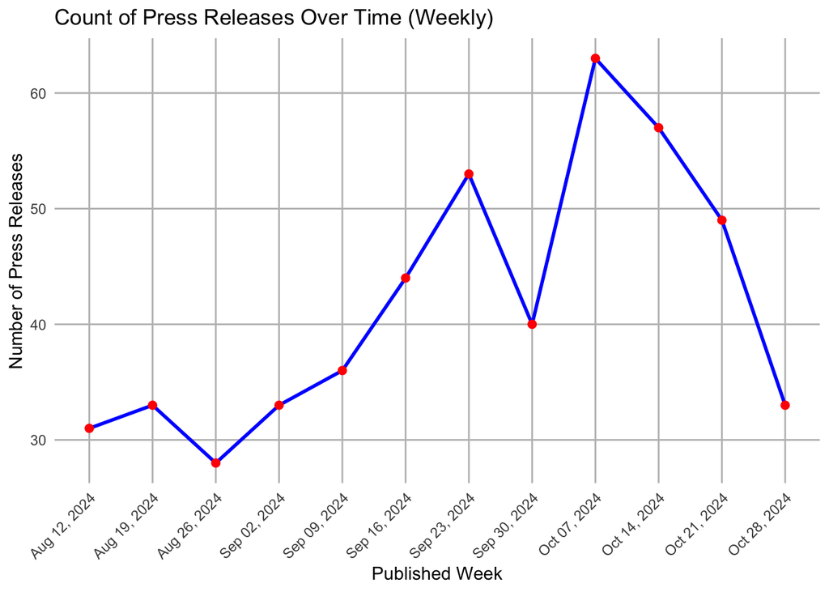

```r
library(tidyverse)
library(janitor)
library(lubridate)

# Clean and preprocess the data
AI_ggplot <- AI_disaster |>
  janitor::clean_names() |>
  mutate(published_date_bak = published_date) |>
  separate(published_date, into = c("date", "year_day"), sep = ", ", extra = "merge", fill = "right") |>
  mutate(date = as.Date(date, format = "%B %d")) |> # Convert to proper date format
  mutate(week = floor_date(date, unit = "week", week_start = 1)) |> # Group by week (starting on Monday)
  group_by(week) |>
  count(week)

# Plotting the data
ggplot(AI_ggplot, aes(x = week, y = n)) +
  geom_line(color = "blue", size = 1) +
  geom_point(color = "red", size = 2) +
  scale_x_date(date_labels = "%b %d, %Y", date_breaks = "1 week") + # Show labels for every week
  labs(
    title = "Count of Press Releases Over Time (Weekly)",
    x = "Published Week",
    y = "Number of Press Releases"
  ) +
  theme_minimal() +
  theme(
    axis.text.x = element_text(angle = 45, hjust = 1),
    panel.grid.major = element_line(size = 0.5, color = "gray"),
    panel.grid.minor = element_blank()
  )
```

#Where most Press Release published

## Visualize of NewsWires and Publishers

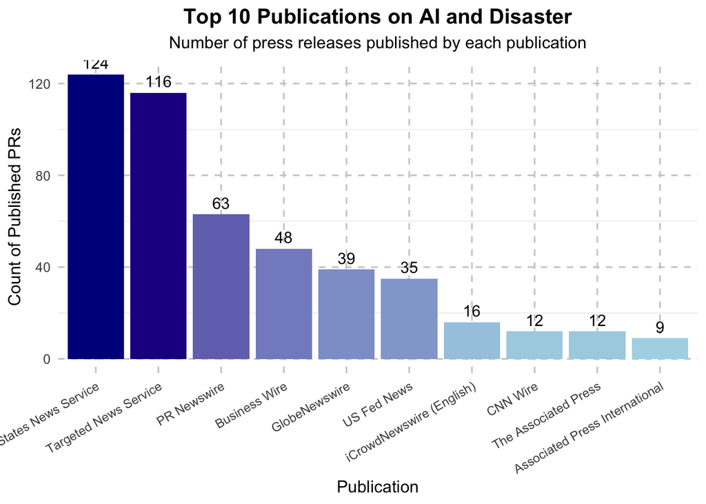

```r
library(ggplot2)
library(ggthemes) # For additional themes

# for a bar chart
ggplot(pr_published_by, aes(x = reorder(publication_4, -pr_published_by), y = pr_published_by, fill = pr_published_by)) +
  geom_bar(stat = "identity", show.legend = FALSE) +
  geom_text(aes(label = pr_published_by), vjust = -0.5, size = 4, color = "black") +
  scale_fill_gradient(low = "lightblue", high = "darkblue") +
  theme_minimal(base_size = 12) +
  labs(
    title = "Top 10 Publications on AI and Disaster",
    subtitle = "Number of press releases published by each publication",
    x = "Publication",
    y = "Count of Published PRs"
  ) +
  theme(
    plot.title = element_text(face = "bold", size = 15, hjust = 0.5),
    plot.subtitle = element_text(size = 12, hjust = 0.5),
    axis.text.x = element_text(angle = 30, hjust = 1, size = 9),
    panel.grid.major = element_line(color = "grey80", linetype = "dashed")
  )
```

## topic modeling

#Loading relevant libraries and packages for topic modelling

### Import Data and process into corpus

```r
topic_data <- articles_df %>%
  select(filename, sentence) %>%
  as.data.frame() %>%
  rename(doc_id = filename, text= sentence)

# load stopwords
english_stopwords <- readLines("https://slcladal.github.io/resources/stopwords_en.txt", encoding = "UTF-8")
# create corpus object
corpus <- Corpus(DataframeSource(topic_data))
# Preprocessing chain
processedCorpus <- tm_map(corpus, content_transformer(tolower))
processedCorpus <- tm_map(processedCorpus, removeWords, english_stopwords)
processedCorpus <- tm_map(processedCorpus, removePunctuation, preserve_intra_word_dashes = TRUE)
processedCorpus <- tm_map(processedCorpus, removeNumbers)
processedCorpus <- tm_map(processedCorpus, stemDocument, language = "en")
processedCorpus <- tm_map(processedCorpus, stripWhitespace)
```

```r
#DTM: rows correspond to the documents in the corpus. Columns correspond to the terms in the documents. Cells correspond to the weights of the terms. (Girder)
# compute document term matrix with terms >= minimumFrequency
minimumFrequency <- 5
DTM <- DocumentTermMatrix(processedCorpus, control = list(bounds = list(global = c(minimumFrequency, Inf))))
# have a look at the number of documents and terms in the matrix
dim(DTM)
```

```
## [1] 90223  7520
```

```r
# due to vocabulary pruning, we have empty rows in our DTM
# LDA does not like this. So we remove those docs from the
# DTM and the metadata
sel_idx <- slam::row_sums(DTM) > 0
DTM <- DTM[sel_idx, ]
topic_data <- topic_data[sel_idx, ]
#5 term minimum[1] 1387 3019
#5 term minimum[1] 308597 10339
```

```r
# number of topics
# K <- 20
K <- 6
# set random number generator seed
set.seed(9161)
#Latent Dirichlet Allocation, LDA
topicModel2 <- LDA(DTM, K, method="Gibbs", control=list(iter = 1000, verbose = 25, alpha = 0.2))
```

```
## K = 6; V = 7520; M = 84907
## Sampling 1000 iterations!
## Iteration 25 ...
## Iteration 50 ...
## Iteration 75 ...
## Iteration 100 ...
## Iteration 125 ...
## Iteration 150 ...
## Iteration 175 ...
## Iteration 200 ...
## Iteration 225 ...
## Iteration 250 ...
## Iteration 275 ...
## Iteration 300 ...
## Iteration 325 ...
## Iteration 350 ...
## Iteration 375 ...
## Iteration 400 ...
## Iteration 425 ...
## Iteration 450 ...
## Iteration 475 ...
## Iteration 500 ...
## Iteration 525 ...
## Iteration 550 ...
## Iteration 575 ...
## Iteration 600 ...
## Iteration 625 ...
## Iteration 650 ...
## Iteration 675 ...
## Iteration 700 ...
## Iteration 725 ...
## Iteration 750 ...
## Iteration 775 ...
## Iteration 800 ...
## Iteration 825 ...
## Iteration 850 ...
## Iteration 875 ...
## Iteration 900 ...
## Iteration 925 ...
## Iteration 950 ...
## Iteration 975 ...
## Iteration 1000 ...
## Gibbs sampling completed!
```

```r
tmResult <- posterior(topicModel2)
theta <- tmResult$topics
beta <- tmResult$terms
topicNames <- apply(terms(topicModel2, 10), 2, paste, collapse = " ")  # reset topicnames
```

### Extracting and visualizing the topics

```r
# Step 1: Check dimensions
n_theta <- nrow(theta)
n_topicdata<- length(topic_data)

cat("Number of rows in theta: ", n_theta, "\n")
```

```
## Number of rows in theta:  84907
```

```r
cat("Number of documents in textdata: ", n_topicdata, "\n")
```

```
## Number of documents in textdata:  2
```

```r
# Check if textdata contains all the documents in theta
common_ids <- intersect(rownames(theta), topic_data$doc_id) # Assuming textdata has a 'doc_id' column

# Filter textdata to include only the documents present in theta
topicdata_filtered <- topic_data[topic_data$doc_id %in% common_ids, ]

# Check dimensions after filtering
n_topicdata_filtered <- nrow(topicdata_filtered)
cat("Number of documents in filtered textdata: ", n_topicdata_filtered, "\n")
```

```
## Number of documents in filtered textdata:  84907
```

```r
# Align rownames of theta with filtered textdata
theta_aligned <- theta[rownames(theta) %in% topicdata_filtered$doc_id, ]

# Step 2: Combine data
full_data <- data.frame(theta_aligned, decade = topicdata_filtered)

# get mean topic proportions per decade
# topic_proportion_per_decade <- aggregate(theta, by = list(decade = textdata$decade), mean)
# set topic names to aggregated columns
colnames(full_data)[2:(K+1)] <- topicNames
# reshape data frame
vizDataFrame <- melt(full_data)
#Examine topic names
#enframe(): Converts a named list into a dataframe.
topics <- enframe(topicNames, name = "number", value = "text") %>%
  unnest(cols = c(text))

topics
```

```
## # A tibble: 6 × 2
##   number  text
##   <chr>   <chr>
## 1 Topic 1 articl page system develop california base sept research issu studi
## 2 Topic 2 program health committe research depart fund agenc univers word educ
## 3 Topic 3 presid trump peopl nation hous state american jean-pierr elect secret…
## 4 Topic 4 develop countri support china global cooper climat intern region secur
## 5 Topic 5 servic news oper net million result quarter financi incom year
## 6 Topic 6 data technolog solut market manag servic innov custom busi cloud
```

Words: program, health, committe, research, depart, fund, agenc, univers, word, educ

**Assessment: This cluster is indicative of Health and Education Programs within governmental and academic institutions. Words like “committee,” “department,” “fund,” and “agency” point to structured organizational efforts, while “university” and “education” emphasize the academic involvement.

**Theme: Health and Education Research Programs in Government and Academia

**Relevance to Project: Health and education sectors often play crucial roles in disaster management. Analyzing how AI is framed within these programs can reveal interdisciplinary approaches and the integration of AI in public health and educational responses to disasters.

Words: presid, trump, peopl, nation, hous, state, american, jean-pierr, elect, secretari

**Assessment: This cluster revolves around Political Leadership and Governance in the United States. The inclusion of “Trump” and “president” highlights discussions related to specific political figures and their administrations. Words like “nation,” “house,” “state,” and “secretary” indicate governance structures and political offices.

**Theme: US Political Leadership and Governance

**Relevance to Project: Political leadership significantly influences disaster response policies and the adoption of AI technologies. Examining this theme can uncover how political narratives and leadership styles shape the framing of AI in disaster management communications.

Words: develop, countri, support, china, global, cooper, climat, intern, region, secur

**Assessment: This cluster pertains to Global Development and International Cooperation, with a focus on Climate and Security Issues. The presence of “China” suggests discussions around international relations, while “climate” and “security” indicate environmental and geopolitical concerns.

**Theme: Global Development, Climate Cooperation, and International Security

**Relevance to Project: AI’s role in addressing global challenges like climate change and international security is pivotal in disaster management. This theme can provide insights into how organizations frame AI as a tool for fostering international cooperation and enhancing global disaster response capabilities.

Words: servic, news, oper, net, million, result, quarter, financi, incom, year

**Assessment: This cluster focuses on Financial Performance and Operations within the Service and News Sectors. Words like “result,” “quarter,” “finance,” “income,” and “year” are indicative of financial reporting and business performance metrics.

**Theme: Financial Performance and Operations of Service and News Sectors

**Relevance to Project: Financial stability and operational efficiency are critical for organizations involved in disaster management. Understanding how AI-related financial results and operational successes are communicated can shed light on the economic framing of AI investments in disaster response.

Words: data, technolog, solut, market, manag, servic, innov, custom, busi, cloud

**Assessment: This cluster is centered around Data Technology Solutions and Cloud-based Business Services. Terms like “data,” “technology,” “solutions,” “market,” “management,” “service,” “innovation,” “custom,” “business,” and “cloud” highlight the focus on technological advancements and business innovations.

**Theme: Data Technology Solutions and Cloud-based Business Services

**Relevance to Project: AI heavily relies on data and cloud technologies for effective disaster management. This theme is directly relevant as it encompasses the technological infrastructure and innovative solutions that organizations leverage, which are likely emphasized in their press releases regarding disaster response.

## Implications for Your Project:

#Diverse Organizational Focus: The identified themes suggest that AI in disaster management is framed across various organizational domains, including research institutions, government agencies, political entities, global cooperatives, financial sectors, and technology companies.

#Interdisciplinary Integration: AI is positioned as a multifaceted tool that intersects with health, education, political governance, global security, financial operations, and technological innovation. This highlights the interdisciplinary nature of AI applications in disaster management.

#Ethical and Risk Considerations: Themes related to governance, international cooperation, and financial operations may incorporate discussions on the ethical implications and risks of AI deployment, aligning with your research objectives.

#Strategic Communication: Understanding these themes can aid in analyzing the strategic narratives organizations use to communicate their AI initiatives, emphasizing benefits, addressing concerns, and positioning themselves within broader socio-political and economic contexts.

#Source of data compiled in your GitHub repository

I am sharing here the source of data that is available at GitHub with new repository named “FramingAI”.

Reposotry : https://github.com/Taufiqahmad92/FramingAI Data : https://github.com/Taufiqahmad92/FramingAI/tree/main/Data